# Análisis Pedidos de Información

lazio

19 de mayo de 2019

# Introducción

Me propuse a explorar los datasets publicos de los Pedidos de Información tanto del Gobierno de la Nación como el del Gobierno de la Ciudad de Buenos aires.

En este archivo encontrarán ambos análisis, uno en cada pestaña.

La idea detras era encontrar cuales eran los temás más solicitados, entender los tiempos de respuesta generales y por area responsable de la respuesta, y ver la evolución en la cantidad de pedidos a lo largo del tiempo.

Para ver dichos resultados, deberan entrar a la pestaña correspondiente a cada gobierno.

Los datasets utilizados se pueden obtener de: Nación: https://datos.gob.ar/dataset/justicia-solicitudes-acceso-informacion-publica-ministerio-justicia-derechos-humanos/archivo/justicia_9417984a-4d69-4160-8b98-030164066285

Ciudad: https://data.buenosaires.gob.ar/dataset/acceso-informacion-publica

## Gobierno de la Nación

### Análisis de Temas

[figure not shown]

### Tiempos de Respuesta General

Luego buscamos encontrar la distribución en los tiempos de respuesta de todos los pedidos. La misma es la siguiente:

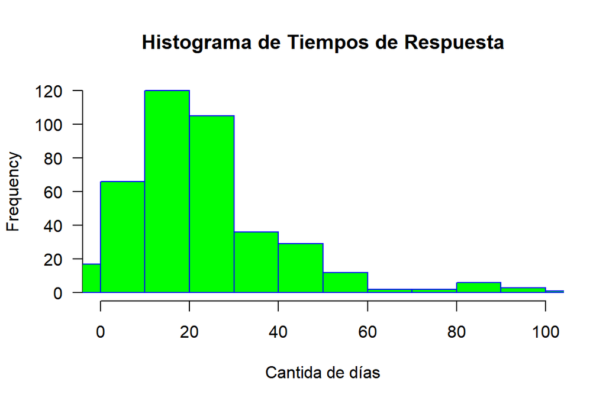

Tambien quise entender si la distribución cambio a lo largo del tiempo, y encontramos que

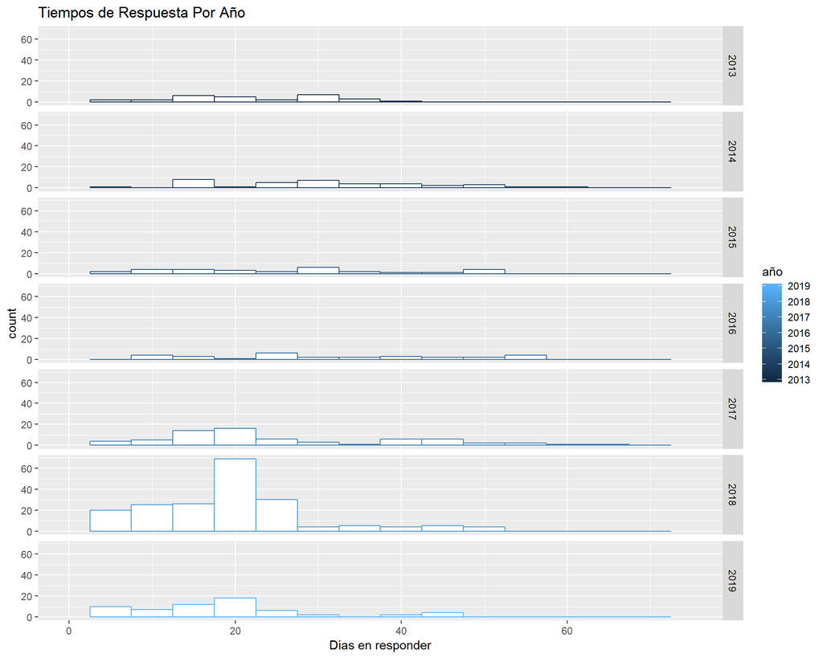

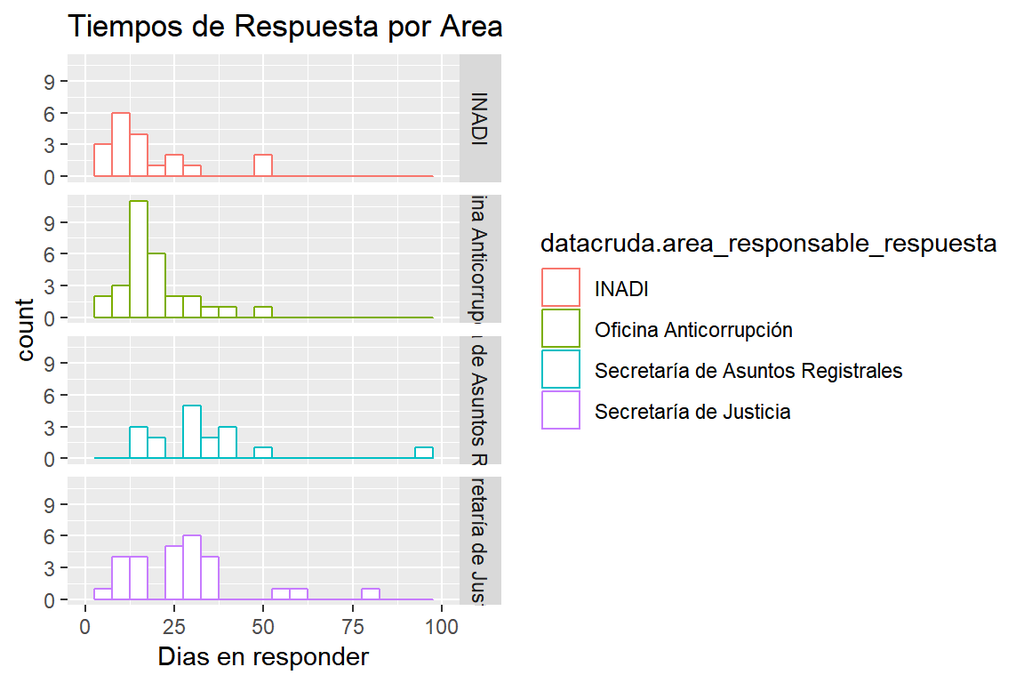

### Evolucion de la cantidad de pedidos

Por último, me interesaba saber si la cantidad de pedidos fue cambiando en el tiempo. A nivel general podemos ver que

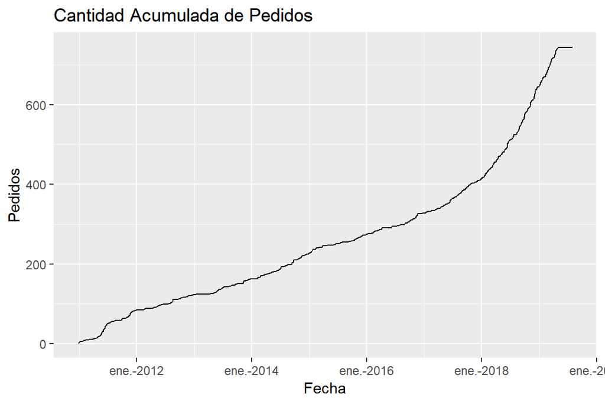

Luego, si lo dividimos por las areas con más pedidos, se observa

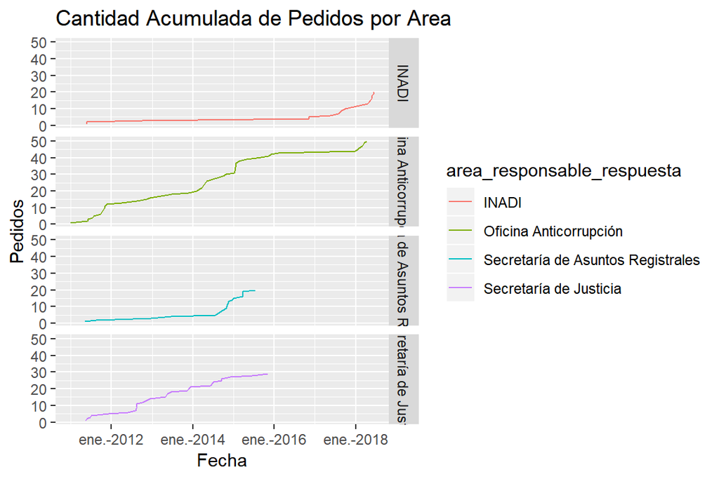

## Gobierno de la Ciudad

### Analisis de Temas

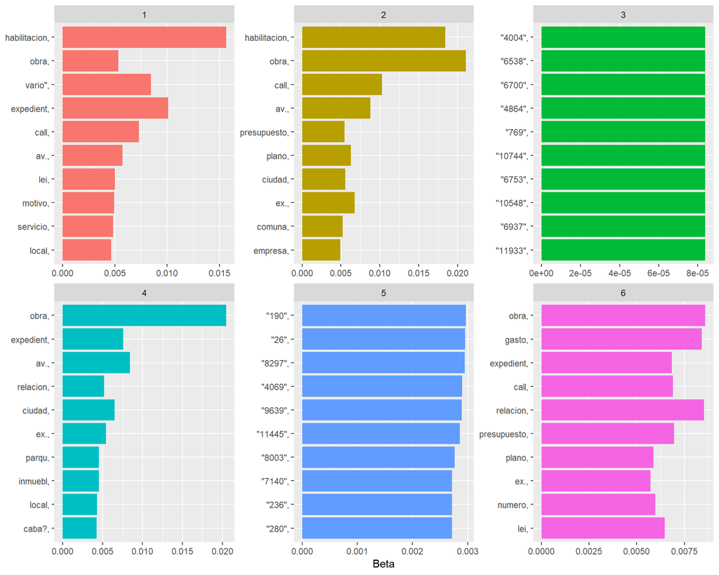

### Tiempos de Respuesta General

Luego buscamos encontrar la distribución en los tiempos de respuesta de todos los pedidos. La misma es la siguiente:

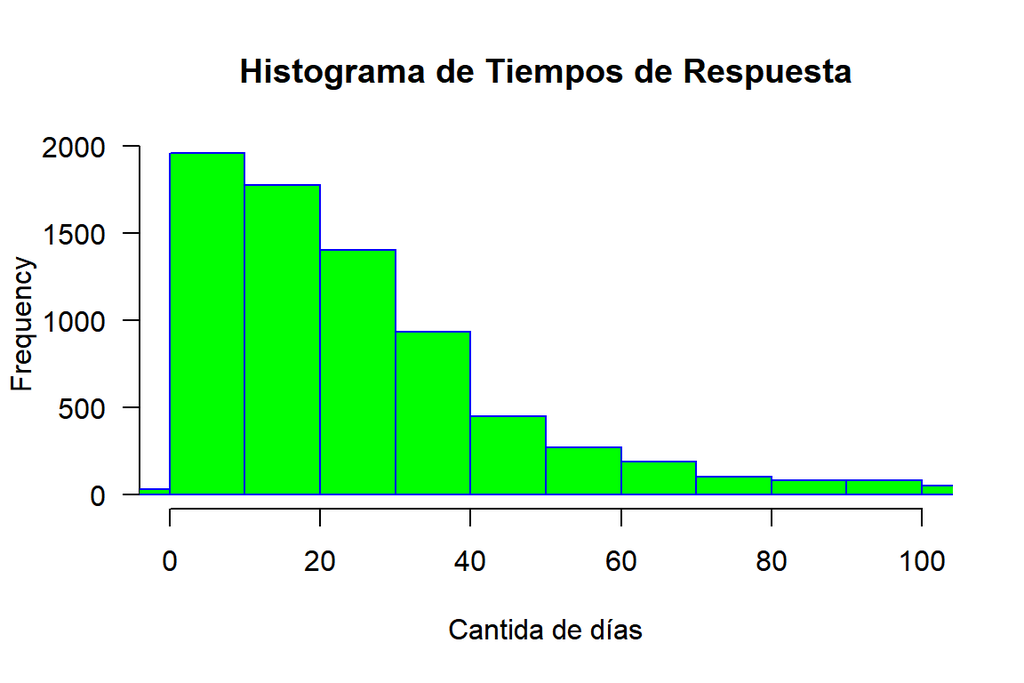

Tambien quise entender si la distribución cambio a lo largo del tiempo, y encontramos que

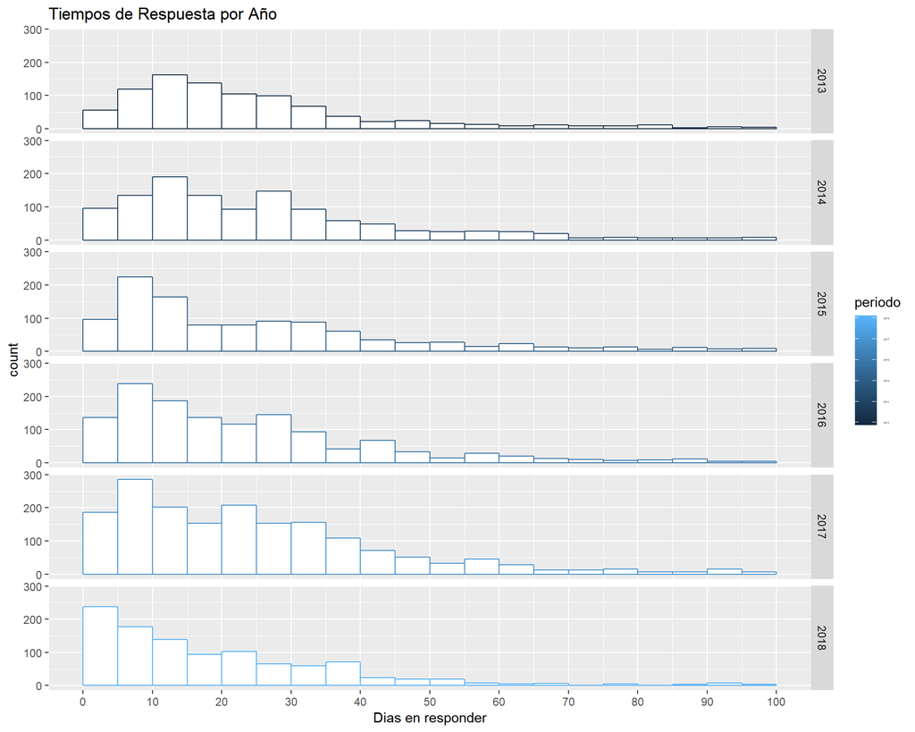

Ademas, me interesaba saber si la distribución era distinta entre las Areas Responsables de Respuesa, asique tomando las 5 con más pedidos, encontramos lo siguiente:

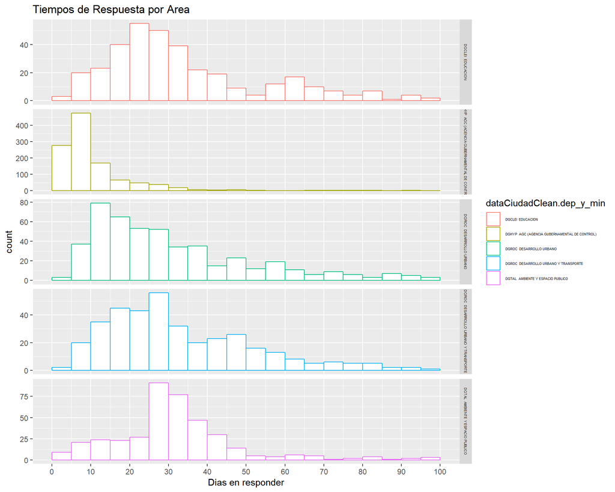

### Evolucion de la cantidad de pedidos

Por último, me interesaba saber si la cantidad de pedidos fue cambiando en el tiempo. A nivel general podemos ver que

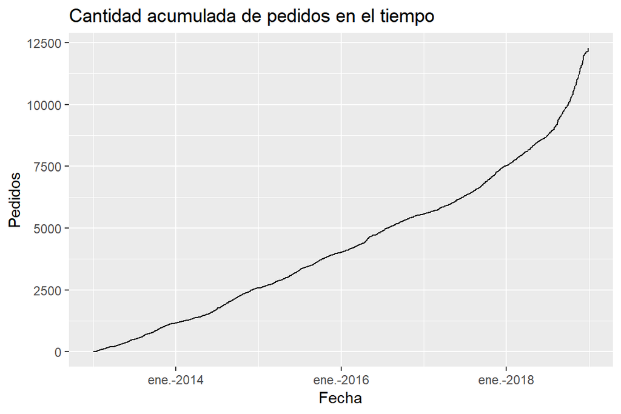

Luego, si lo dividimos por las areas con más pedidos, se observa

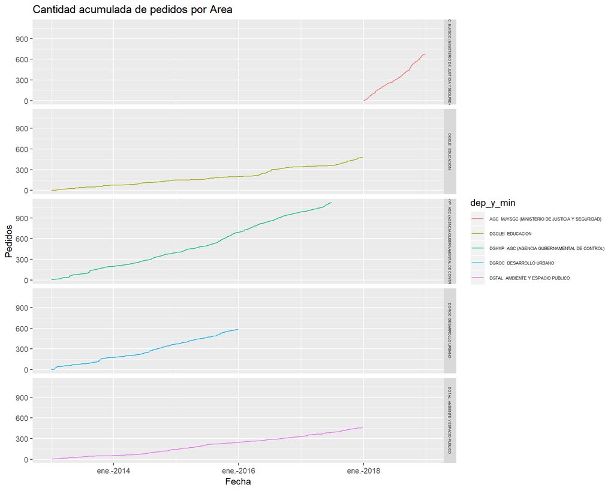